# week 2 chapter 4

Pablo Bello

9/8/2022

# Chapter 4

Chapter 4 is fairly comprehensive but let’s do a couple more things to get more comfortable with reading in data and transforming it into a tidy format.

Let’s load the collection of packages we usually rely on:

```r
library(tidyverse)
```

## Question 1

We have done this a couple of times but I want to reinforce how handy of a trick this is. It turns out you can read in data directly from the internet.

Go to this [link](https://github.com/NicolasRestrep/223_course/blob/main/Data/nfl_salaries.csv). Yes, I recognize that this is the course repository. Yes, I recognize you also have this data because you cloned into the repository. But this is useful I promise.

Then, click on a button that says `Raw`. Once you see the the raw data, copy the link. Now, use `read_csv` but pass the link (inside quotation marks) as an argument.

```r
nfl_salaries <- read_csv("https://raw.githubusercontent.com/NicolasRestrep/223_course/main/Data/nfl_salaries.csv")
```

## Question 2

This dataset is clearly not in a tidy format. Reshape it so that every row tells you the salary associated with a position each year. Your new dataset should have three columns: `year`, `position`, `salary`.

```r
(nfl_long <-
  nfl_salaries |>
  pivot_longer(cols = 2:ncol(nfl_salaries),
               values_to = "salary",
               names_to = "position"))
```

```
## # A tibble: 8,000 × 3
##     year position            salary
##    <dbl> <chr>                <dbl>
##  1  2011 Cornerback        11265916
##  2  2011 Defensive Lineman 17818000
##  3  2011 Linebacker        16420000
##  4  2011 Offensive Lineman 15960000
##  5  2011 Quarterback       17228125
##  6  2011 Running Back      12955000
##  7  2011 Safety             8871428
##  8  2011 Special Teamer     4300000
##  9  2011 Tight End          8734375
## 10  2011 Wide Receiver     16250000
## # … with 7,990 more rows
```

## Question 3

Of course, there are many folks in each position and their salaries vary widely. Let’s look at quarterbacks for example. Filter your newly created dataset so that it only contains quarterbacks. Then, make a histogram where salary is in the x-axis. Then use `facet_wrap` to get the histogram for each `year`.

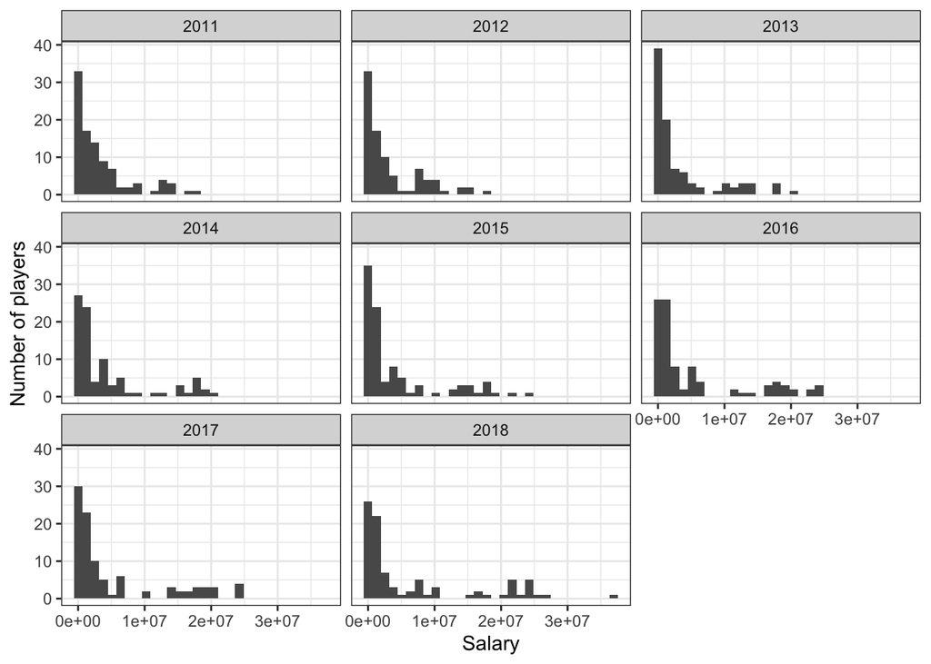

```r
nfl_long |>
  filter(position == "Quarterback") |>
  ggplot(aes(salary)) +
  geom_histogram() +
  labs(y = "Number of players",
       x = "Salary") +
  theme_bw() +
  facet_wrap(~ year)
```

What patterns do you notice?

**There is a longer tail (a few really high salaries) in more recent years.**

## Question 4

Let’s calculate the average salary for each position, each year. Create a new dataset that contains the average salary for each position each year. To do this, you will need the `group_by` and `summarize` combo.

```r
(nfl_long_s <-
  nfl_long |>
  group_by(position,year) |>
  summarise(av_salary = mean(salary,na.rm = TRUE)))
```

```
## # A tibble: 80 × 3
## # Groups:   position [10]
##    position           year av_salary
##    <chr>             <dbl>     <dbl>
##  1 Cornerback         2011  3037766.
##  2 Cornerback         2012  3132916.
##  3 Cornerback         2013  2901798.
##  4 Cornerback         2014  3038278.
##  5 Cornerback         2015  3758543.
##  6 Cornerback         2016  4201470.
##  7 Cornerback         2017  4125692.
##  8 Cornerback         2018  4659704.
##  9 Defensive Lineman  2011  4306995.
## 10 Defensive Lineman  2012  4693730.
## # … with 70 more rows
```

> Hint: Beware of a couple of NAs in there

## Question 5

Make a linegraph that traces the evolution of each position’s average salary across the years. You can use use different strategies to distinguish between positions - color or facets for example. What is important is that you see each position’s trajectory clearly and that they are comparable.

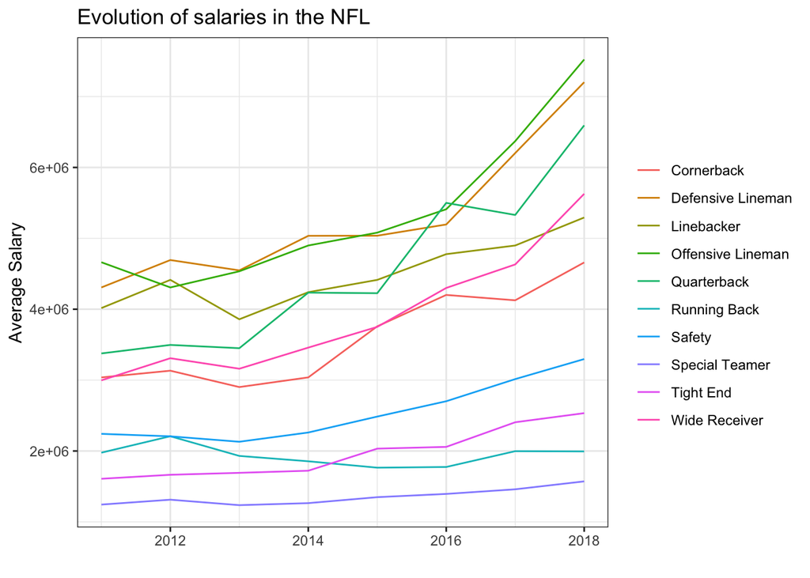

```r
nfl_long_s |>
  ggplot(aes(year,av_salary, group = position, color = position)) +
  geom_line() +
  labs(x = "",
       y = "Average Salary",
       color = "",
       title = "Evolution of salaries in the NFL") +
  theme_bw()
```

Describe at least two trends that are apparent to you.